# Storm Events Database - A look at the most dangerous storm events in USA

Giacinto Maggiore

March,29 2016

NWS’s Storm Events Database contains the data about significant meteorological events, that are relevant for the public opinion or that have sufficient intensity to cause loss of life, injuries and economic consequences.

Our goal is to determine which types of storm events are more harmful for the people health and which types have the greatest economic consequences.

## Data Processing

```r
#Load the required packages
if (!require("dplyr")) install.packages("dplyr")
if (!require("ggplot2")) install.packages("ggplot2")
if (!require("reshape2")) install.packages("reshape2")
```

The data for this assignment come in the form of a comma-separated-value file compressed via the bzip2 algorithm to reduce its size. The uncrompressed file has a size of 410 MB.

There is also some documentation of the database available:

[NWS Storm Data Documentation](https://d396qusza40orc.cloudfront.net/repdata%2Fpeer2_doc%2Fpd01016005curr.pdf)

Data was downloaded and loaded into a dplyr tbl.

```r
#Load the data
if(!dir.exists("Data")){

      dir.create("Data")
}

dirData<-"Data/stormData.csv.bz2"   #49 Mb -> uncompressed 409.4 Mb

if(!file.exists(dirData)){
      url<-
      "https://d396qusza40orc.cloudfront.net/repdata%2Fdata%2FStormData.csv.bz2"
      message("Download in progress.")
      download.file(url,dirData)
      message("Download completed.")
}
stormData<-tbl_df(read.csv(dirData))     #Take a long time - BE PATIENT
```

The stormData contains a lot of information as it can be seen:

```r
names(stormData)
```

```
##  [1] "STATE__"    "BGN_DATE"   "BGN_TIME"   "TIME_ZONE"  "COUNTY"
##  [6] "COUNTYNAME" "STATE"      "EVTYPE"     "BGN_RANGE"  "BGN_AZI"
## [11] "BGN_LOCATI" "END_DATE"   "END_TIME"   "COUNTY_END" "COUNTYENDN"
## [16] "END_RANGE"  "END_AZI"    "END_LOCATI" "LENGTH"     "WIDTH"
## [21] "F"          "MAG"        "FATALITIES" "INJURIES"   "PROPDMG"
## [26] "PROPDMGEXP" "CROPDMG"    "CROPDMGEXP" "WFO"        "STATEOFFIC"
## [31] "ZONENAMES"  "LATITUDE"   "LONGITUDE"  "LATITUDE_E" "LONGITUDE_"
## [36] "REMARKS"    "REFNUM"
```

```r
stormData
```

```
## Source: local data frame [902,297 x 37]
##
##    STATE__           BGN_DATE BGN_TIME TIME_ZONE COUNTY COUNTYNAME  STATE
##      (dbl)             (fctr)   (fctr)    (fctr)  (dbl)     (fctr) (fctr)
## 1        1  4/18/1950 0:00:00     0130       CST     97     MOBILE     AL
## 2        1  4/18/1950 0:00:00     0145       CST      3    BALDWIN     AL
## 3        1  2/20/1951 0:00:00     1600       CST     57    FAYETTE     AL
## 4        1   6/8/1951 0:00:00     0900       CST     89    MADISON     AL
## 5        1 11/15/1951 0:00:00     1500       CST     43    CULLMAN     AL
## 6        1 11/15/1951 0:00:00     2000       CST     77 LAUDERDALE     AL
## 7        1 11/16/1951 0:00:00     0100       CST      9     BLOUNT     AL
## 8        1  1/22/1952 0:00:00     0900       CST    123 TALLAPOOSA     AL
## 9        1  2/13/1952 0:00:00     2000       CST    125 TUSCALOOSA     AL
## 10       1  2/13/1952 0:00:00     2000       CST     57    FAYETTE     AL
## ..     ...                ...      ...       ...    ...        ...    ...
## Variables not shown: EVTYPE (fctr), BGN_RANGE (dbl), BGN_AZI (fctr),
##   BGN_LOCATI (fctr), END_DATE (fctr), END_TIME (fctr), COUNTY_END (dbl),
##   COUNTYENDN (lgl), END_RANGE (dbl), END_AZI (fctr), END_LOCATI (fctr),
##   LENGTH (dbl), WIDTH (dbl), F (int), MAG (dbl), FATALITIES (dbl),
##   INJURIES (dbl), PROPDMG (dbl), PROPDMGEXP (fctr), CROPDMG (dbl),
##   CROPDMGEXP (fctr), WFO (fctr), STATEOFFIC (fctr), ZONENAMES (fctr),
##   LATITUDE (dbl), LONGITUDE (dbl), LATITUDE_E (dbl), LONGITUDE_ (dbl),
##   REMARKS (fctr), REFNUM (dbl)
```

Most of the information is not relevant to the analysis. The code following extracts the required data for health and economic impact analysis against weather.

```r
stormData<-select(stormData,EVTYPE,FATALITIES,INJURIES,PROPDMG,PROPDMGEXP,
                 CROPDMG,CROPDMGEXP)
```

The variables are:

- EVTYPE storm event type
- FATALITIES numbers of fatalities
- INJURIES numbers of injuries
- PROPDMG property damage in USD
- PROPDMGEXP magnitude of the property damage (exponent)
- CROPDMG crop damage in USD
- CROPDMGEXP magnitude of the crop damage (exponent)

It is necessary to compute the sum of fatalaties and injuries and the total economic impact for each event type. The PROPDMGEXP and CROPDMGEXP contain some character for indicating the magnitude of the corresponding damage.

```r
table(stormData$PROPDMGEXP)
```

```
##
##             -      ?      +      0      1      2      3      4      5
## 465934      1      8      5    216     25     13      4      4     28
##      6      7      8      B      h      H      K      m      M
##      4      5      1     40      1      6 424665      7  11330
```

```r
table(stormData$CROPDMGEXP)
```

```
##
##             ?      0      2      B      k      K      m      M
## 618413      7     19      1      9     21 281832      1   1994
```

All the characters are substituted with the corresponding numerical exponential. The characters “?”, “-”,“+”,“” are replaced by 1.

```r
stormData$PROPDMGEXP<-
      plyr::mapvalues(stormData$PROPDMGEXP, from =
                                      c("","-","?","+","0","1","2","3","4",
                                        "5","6","7","8","B","h","H","K","m","M"),
                                      to =
                                      c("0","0","0","0","0","1","2","3","4","5",
                                        "6","7","8","9","2","2","3","6","6"))

stormData$CROPDMGEXP<-
      plyr::mapvalues(stormData$CROPDMGEXP, from =
                                      c("","?","0","2","B","k","K","m","M"),
                                      to =
                                      c("0","0","0","2","9","3","3","6","6"))

stormData$PROPDMGEXP<-as.numeric(as.character(stormData$PROPDMGEXP))
stormData$CROPDMGEXP<-as.numeric(as.character(stormData$CROPDMGEXP))
```

The total economic damages and total healt damages are computed by the following code. They are been stored in the data frame in the variables TOT_HEALTHDMG and TOT_ECONOMICDMG.

```r
stormData<-
      stormData %>%
            mutate(
                  PROPDMG = PROPDMG*10^PROPDMGEXP,
                  CROPDMG = CROPDMG*10^CROPDMGEXP) %>%
            group_by(EVTYPE) %>%
            summarise(
                       FATALITIES = sum(FATALITIES),INJURIES = sum(INJURIES),
                       PROPDMG = sum(PROPDMG), CROPDMG = sum(CROPDMG)
                      ) %>%
            mutate(
                     TOT_HEALTHDMG = FATALITIES + INJURIES,
                     TOT_ECONOMICDMG = PROPDMG + CROPDMG
                  )
```

```r
head(stormData)
```

```
## Source: local data frame [6 x 7]
##
##                  EVTYPE FATALITIES INJURIES PROPDMG CROPDMG TOT_HEALTHDMG
##                  (fctr)      (dbl)    (dbl)   (dbl)   (dbl)         (dbl)
## 1    HIGH SURF ADVISORY          0        0  200000       0             0
## 2         COASTAL FLOOD          0        0       0       0             0
## 3           FLASH FLOOD          0        0   50000       0             0
## 4             LIGHTNING          0        0       0       0             0
## 5             TSTM WIND          0        0 8100000       0             0
## 6       TSTM WIND (G45)          0        0    8000       0             0
## Variables not shown: TOT_ECONOMICDMG (dbl)
```

## Results

A new data frame, containing the first ten rows of storm events that are the most harmful for the health people,is constructed.Then a bar plot, that respresents the TOP 10 of event types for injuries and fatalities, is plotted.

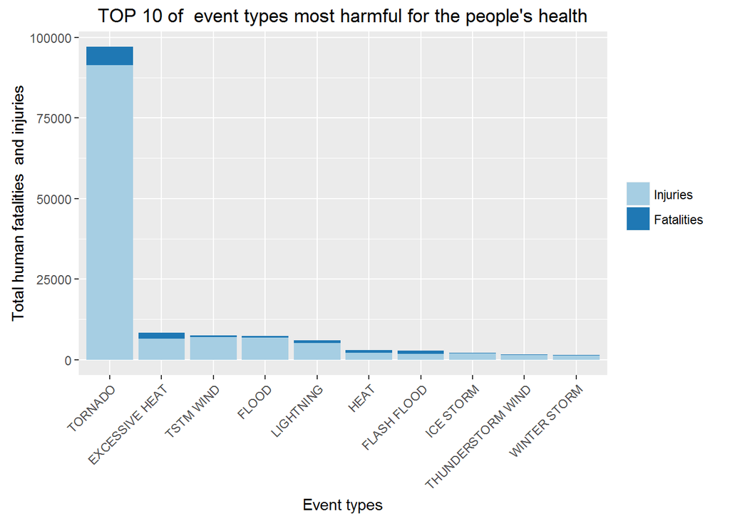

```r
totalHealthData<-arrange(stormData,desc(TOT_HEALTHDMG))[1:10, ] #select TOP 10
totalHealthData$EVTYPE<-as.factor(as.character(totalHealthData$EVTYPE))
totalHealthData$EVTYPE <- factor(
                              totalHealthData$EVTYPE,
                              levels = totalHealthData$EVTYPE) #order levels


totalHealthData<-melt(totalHealthData,
                      id = "EVTYPE",
                      measure.vars = c("INJURIES", "FATALITIES"))

p1<-ggplot(totalHealthData, aes(x = EVTYPE, y = value, fill = variable)) +
      geom_bar(stat = "identity") +
      scale_fill_brewer(
            palette="Paired",
            labels=c("Injuries", "Fatalities"))+
      xlab("Event types")+
      ylab("Total human fatalities  and injuries") +
      ggtitle("TOP 10 of  event types most harmful for the people's health") +
      theme(
            axis.text.x = element_text(angle = 45, hjust = 1),
            legend.title=element_blank()
            )

print(p1)
```

The event that is the most harmful for people’s health is Tornado. The second one most harmful is the excessive heat, but it causes much less vicitims than tornadoes.

In the same way a bar plot, representing the TOP 10 of the storm event type for economic consequences, is constructed.

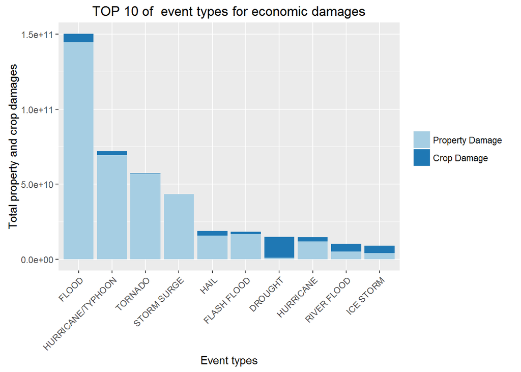

```r
totalEconomicData<-arrange(stormData,desc(TOT_ECONOMICDMG))[1:10, ]
totalEconomicData$EVTYPE<-as.factor(as.character(totalEconomicData$EVTYPE))
totalEconomicData$EVTYPE <- factor(totalEconomicData$EVTYPE, levels = totalEconomicData$EVTYPE)


totalEconomicData<-melt(totalEconomicData,
                      id = "EVTYPE",
                      measure.vars = c("PROPDMG", "CROPDMG"))



p2<-ggplot(totalEconomicData, aes(x = EVTYPE, y = value, fill = variable)) +
      geom_bar(stat = "identity") +
      scale_fill_brewer(
            palette="Paired",
            labels=c("Property Damage", "Crop Damage")
            )+
      xlab("Event types")+
      ylab("Total property and crop damages") +
      ggtitle("TOP 10 of  event types for economic damages") +
      theme(axis.text.x = element_text(angle = 45, hjust = 1),
            legend.title=element_blank())

print(p2)
```

The event that causes the greates economic damages is flood. Typhoons and Tornadoes are respectively the second and third ones.